# Tree Algorithm

Author

Luying Shu

# Modern Tree Algorithms (1980s)

## CART (Classification and Regression Trees)

**Work:**  
Breiman, L., Friedman, J. H., Olshen, R. A., & Stone, C. J. (1984). *Classification and Regression Trees*. Wadsworth.

**Contribution:**  
A landmark work that systematically introduced the theoretical framework of decision trees. It proposed the use of a **binary tree structure**, **recursive binary splitting**, and specific split criteria: **Gini impurity** for classification and **mean squared error (MSE)** for regression. It also formalized **cost-complexity pruning**, laying the foundation for modern decision tree methods.

**Key Contributions:**

- Gini impurity (for classification)
- Regression trees (based on MSE)
- Systematic cost-complexity pruning theory

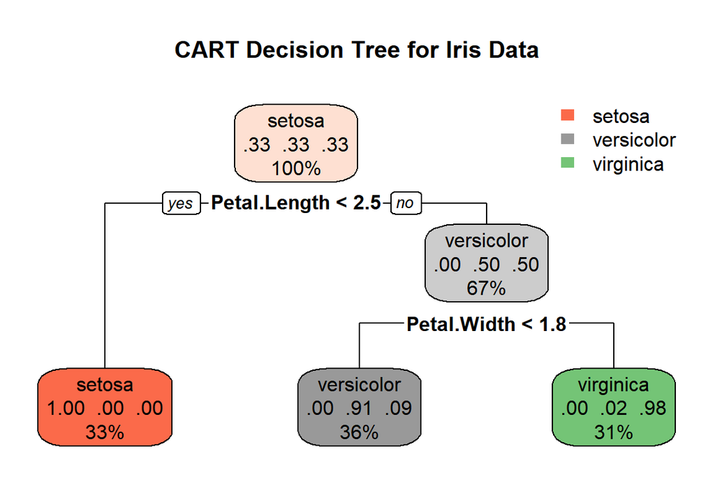

```r
library(rpart)
library(rpart.plot)
library(MASS)

# Tree building
cart_model <- rpart(Species ~ ., data = iris, method = "class")
rpart.plot(cart_model, main = "CART Decision Tree for Iris Data", extra = 104)
```

Gini impurity and MSE are the criteria used to determine splitting “at tree building”, while CP is the criterion used to evaluate whether a subtree is worth keeping “at pruning”.

| Item | Gini Impurity / Entropy / MSE | CP (Complexity Parameter) |
| --- | --- | --- |
| Purpose | Decides **whether and where to split** a node | Decides **whether to keep a subtree** (pruning) |
| Application | **Tree growth phase** (building from an empty tree) | **Pruning phase** (cutting back from a large tree) |
| In classification trees | Gini impurity or entropy | Misclassification rate, Gini, or `xerror` (cross-validation error) |
| In regression trees | MSE (Mean Squared Error) | RSS (Residual Sum of Squares) or cross-validation error |

```r
printcp(cart_model)
```

```
Classification tree:
rpart(formula = Species ~ ., data = iris, method = "class")

Variables actually used in tree construction:
[1] Petal.Length Petal.Width

Root node error: 100/150 = 0.66667

n= 150

    CP nsplit rel error xerror     xstd
1 0.50      0      1.00   1.15 0.051801
2 0.44      1      0.50   0.63 0.060448
3 0.01      2      0.06   0.08 0.027520
```

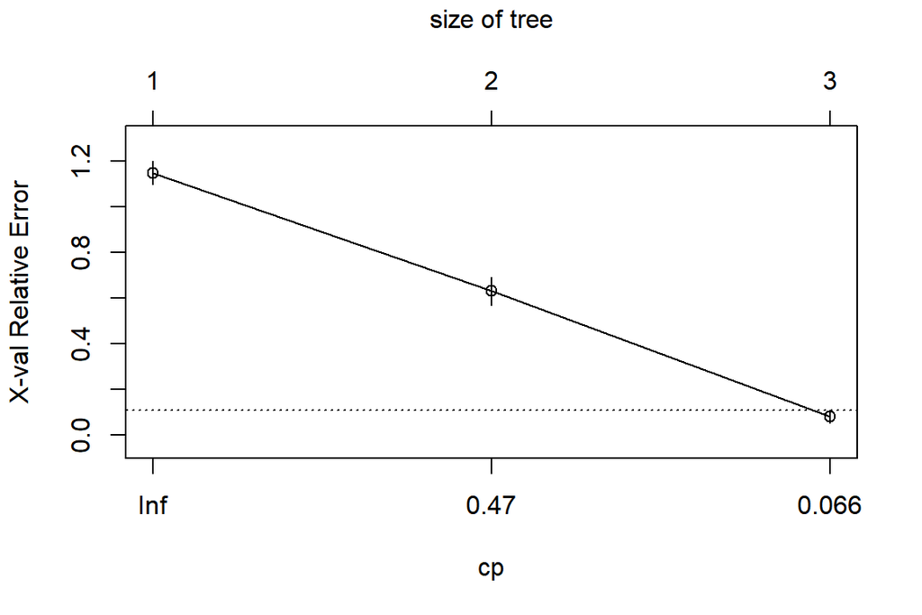

```r
plotcp(cart_model)
```

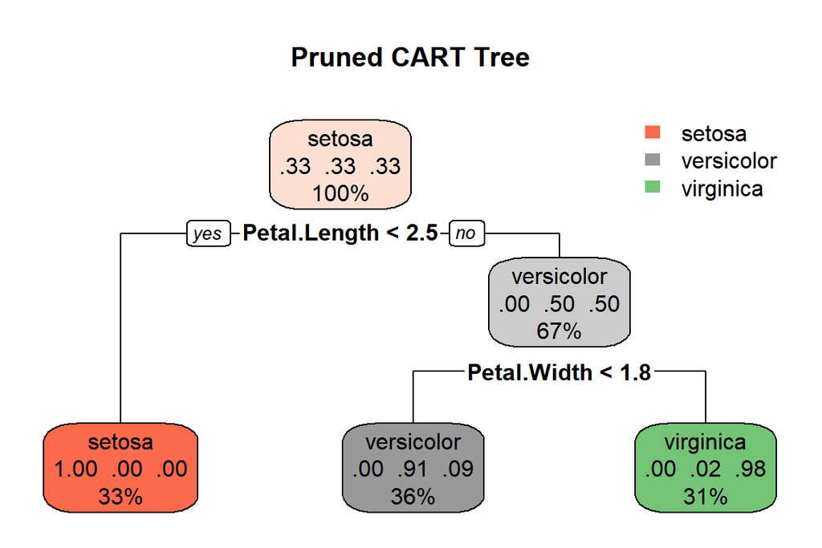

```r
# Select the optimal cp (with the minimum cross-validation error)
opt_cp <- cart_model$cptable[which.min(cart_model$cptable[,"xerror"]), "CP"]
# Prune the tree using the optimal cp
pruned_model <- prune(cart_model, cp = opt_cp)
# Visualize the pruned decision tree
rpart.plot(pruned_model, main = "Pruned CART Tree", extra = 104)
```

### Feature Importance

In CART (Classification and Regression Trees), **variable importance** is computed by analyzing how much each variable contributes to the reduction of node impurity across the entire tree.

General Definition

For a given variable $X_j$, its importance is computed as:

$$\text{Importance}(X_j) = \sum_{t \in \text{splits using } X_j} \Delta \text{Impurity}_t$$

That is, we sum the impurity reduction $\Delta \text{Impurity}$ achieved by all splits that use $X_j$.

```r
pruned_model$variable.importance
```

```
 Petal.Width Petal.Length Sepal.Length  Sepal.Width
    88.96940     81.34496     54.09606     36.01309
```

## ID3 (Iterative Dichotomiser 3)

**Work:**  
Quinlan, J. R. (1986). *Induction of Decision Trees*. *Machine Learning*, *1*(1), 81–106.

**Contribution:**  
An algorithm designed specifically for classification tasks. Its key innovation was the use of **information gain** (based on entropy from information theory) as the splitting criterion. Unlike CART, ID3 constructs **multiway splits** instead of binary trees.

**Key Contribution:** - Information gain as a splitting criterion

## C4.5 (An Evolution of ID3)

**Work:**  
Quinlan, J. R. (1993). *C4.5: Programs for Machine Learning*. Morgan Kaufmann.

**Contribution:**  
A major enhancement of ID3. Key innovations include:

- **Gain Ratio:** A normalized version of information gain that reduces bias toward attributes with many values
- **Handling of Continuous Attributes:** Automatically discretizes continuous features
- **Missing Value Handling:** Introduces strategies for dealing with missing data
- **Pruning Techniques:** Includes methods such as pessimistic error pruning and statistical tests (e.g., chi-squared pruning)

**Impact:**  
C4.5 became one of the most widely used and influential single-tree decision tree algorithms for many years.

```r
library(ISLR2)
library(tidyverse)
library(MASS)
data(kyphosis)
```

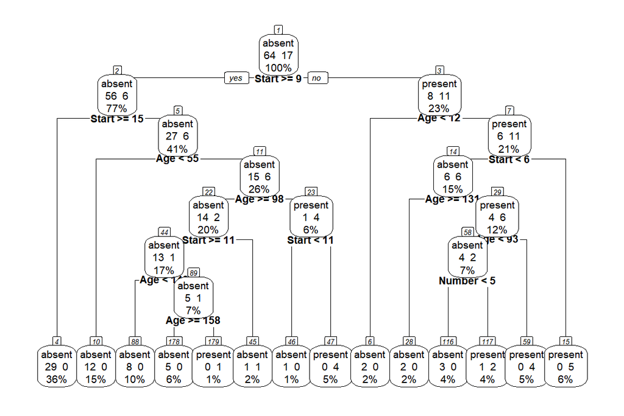

```r
kmod <- rpart(Kyphosis ~ Age + Number + Start, method="class", data=kyphosis, control = rpart.control(cp = 0, minbucket = 1))
prp(kmod, type = 2, extra = 101, nn = TRUE, fallen.leaves = TRUE, cex = 0.6)
```

```r
# kmod$frame
```

```r
kmod$cptable
```

```
          CP nsplit rel error   xerror      xstd
1 0.17647059      0 1.0000000 1.000000 0.2155872
2 0.11764706      1 0.8235294 1.352941 0.2387187
3 0.07843137      2 0.7058824 1.176471 0.2282908
4 0.05882353      5 0.4705882 1.235294 0.2320031
5 0.01960784     10 0.1764706 1.235294 0.2320031
6 0.00000000     13 0.1176471 1.294118 0.2354756
```

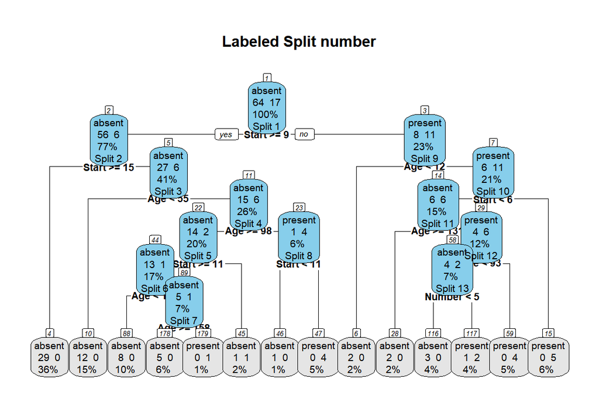

```r
frame <- kmod$frame
node_ids <- as.numeric(rownames(frame))

split_nodes <- node_ids[frame$var != "<leaf>"]
split_labels <- paste0("Split ", seq_along(split_nodes))
label_df <- data.frame(node_id = split_nodes, label = split_labels)

custom_node_fun <- function(x, labs, digits, varlen) {
  nid <- as.numeric(rownames(x$frame))
  label <- label_df$label[match(nid, label_df$node_id)]
  paste(labs, ifelse(!is.na(label), paste0("\n", label), ""))
}

prp(kmod,
    type = 2, extra = 101, nn = TRUE,
    fallen.leaves = TRUE,
    box.col = ifelse(frame$var == "<leaf>", "gray90", "skyblue"),
    node.fun = custom_node_fun,
    main = "Labeled Split number", cex = 0.6)
```

| Column | Meaning |
| --- | --- |
| `CP` | **Complexity Parameter**: The minimum relative error reduction obtained by pruning the current split node and its entire subtree. |
| `nsplit` | **Number of Splits**: The number of splits retained in the current subtree (i.e., number of internal decision nodes). |
| `rel error` | **Relative Training Error**: The relative error of the current subtree on the training data, scaled so that the root node has error 1. |
| `xerror` | **Relative Cross-Validation Error**: The relative error of the current subtree evaluated via cross-validation; used to select the optimal subtree. |
| `xstd` | **Standard Deviation of Cross-Validation Error**: The standard error of `xerror`, used to construct error bars when identifying the minimum cost-complexity subtree. |

What is the Default Error Measure $R(t)$ in `rpart`?

The default error measure depends on the `method` specified in the `rpart()` function:

| `method` Argument | Default Error Measure $R(t)$ | Description |
| --- | --- | --- |
| `"class"` | **Misclassification error** | $R(t) = 1 - \max(p_i)$, where $p_i$ is the proportion of the majority class at node $t$ |
| `"anova"` | **Residual Sum of Squares (RSS)** | $R(t) = \sum (y_i - \bar{y}_t)^2$ |
| `"poisson"` | **Deviance (Likelihood-based)** | Used for count data |
| `"exp"` | **Exponential Deviance (Survival)** | Used for censored data models |

Example code for Pruning Results with Split Numbering

```r
# cp_opt <- 0.05882353
# pruned_model <- prune(kmod, cp = cp_opt)
# frame <- pruned_model$frame
# node_ids <- as.numeric(rownames(frame))
#
# split_nodes <- node_ids[frame$var != "<leaf>"]
# split_labels <- paste0("Split ", seq_along(split_nodes))
# label_df <- data.frame(node_id = split_nodes, label = split_labels)
#
# prp(pruned_model,
#     type = 2, extra = 101, nn = TRUE,
#     fallen.leaves = TRUE,
#     box.col = ifelse(frame$var == "<leaf>", "gray90", "skyblue"),
#     node.fun = custom_node_fun,
#     main = "Labeled Split number (Pruned Tree)", cex = 0.6)
```

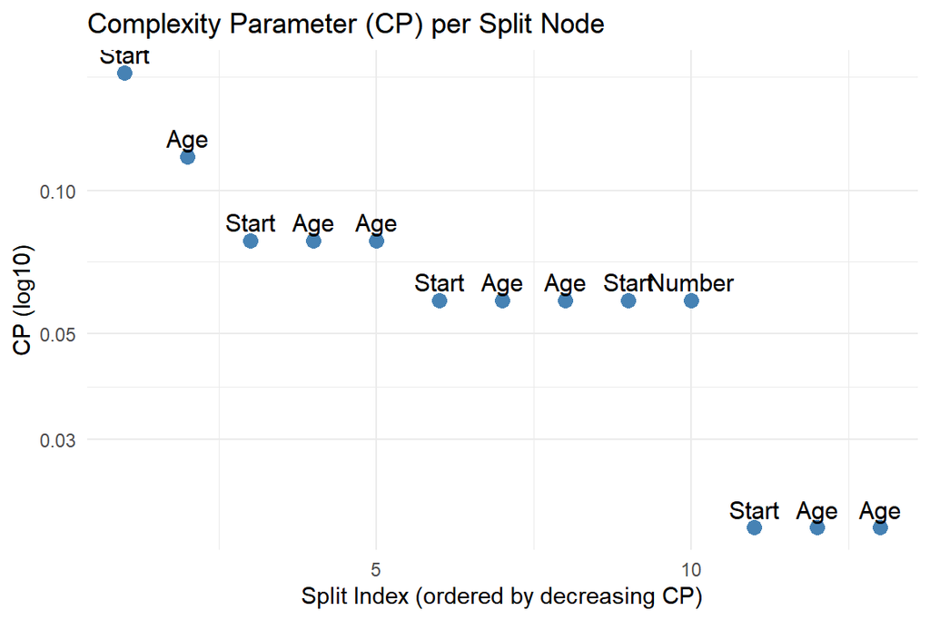

```r
# Extract model structure
frame <- kmod$frame
node_ids <- as.numeric(rownames(frame))

# Extract non-leaf nodes (i.e., split points)
split_nodes <- node_ids[frame$var != "<leaf>"]
split_cp <- frame$complexity[frame$var != "<leaf>"]

# Create data frame
cp_df <- data.frame(
  Node = split_nodes,
  SplitVariable = frame$var[frame$var != "<leaf>"],
  CP = split_cp
)

# Sort by CP
cp_df <- cp_df %>% arrange(desc(CP)) %>%
  mutate(SplitIndex = row_number())

# Plot
library(ggplot2)
ggplot(cp_df, aes(x = SplitIndex, y = CP, label = SplitVariable)) +
  geom_point(size = 3, color = "steelblue") +
  geom_text(vjust = -0.5, size = 4) +
  scale_y_log10() +  # log scale for clarity
  labs(title = "Complexity Parameter (CP) per Split Node",
       x = "Split Index (ordered by decreasing CP)", y = "CP (log10)") +
  theme_minimal()
```

Each point represents a non-terminal node (i.e., a split point) in the decision tree. The label indicates the variable used for that particular split (e.g., “Start”, “Age”, “Number”). This plot visualizes the most influential splits (those with the greatest reduction in error), the most frequently used variables, and the diminishing marginal effectiveness of splits, as reflected by the exponentially decreasing complexity parameter (CP) on a log scale.

Therefore, although the tree after split 3 may be simpler, it is not favored under the cost-complexity pruning criterion if pruning additional splits (e.g., 4 and 5) yields the same CP but a larger reduction in overall error. In such cases, the intermediate state is omitted from the table because it does not improve the cost-complexity trade-off.

## Interpretation: Variable Importance

There are two ways to report variable importance:

`kmod$variable.importance`: unscaled raw scores—the total reduction in impurity (e.g., Gini index, information gain, or RSS) contributed by each variable across all splits in the tree.

`summary(kmod)` → “Variable importance”: the same raw scores rescaled to integer percentages that sum to 100.

```r
kmod$variable.importance
```

```
    Start       Age    Number
13.780608 12.436761  3.208137
```

```r
# summary(kmod)
```

Method 1 — Deviance Drop per Node For a variable *var*:

$$\text{Importance}_{\text{var}}
=\sum_{\text{splits on var}}
\bigl(
D_{\text{parent}}
-D_{\text{left}}
-D_{\text{right}}
\bigr)$$

where $D$ is the node deviance (Gini, entropy, RSS, …).

```r
library(rpart)
library(ISLR2)
library(tidyverse)

# ===============================================
# How variable.importance is computed
# ===============================================
# 1. For each split node, compute the impurity improvement
# 2. Accumulate the improvement for every variable that is used in a split
# 3. Surrogate splits also contribute, weighted by their agreement
# 4. Finally, normalise the totals (rpart leaves them un-scaled; summary() rescales)

# ---------- Method 1: simple deviance-drop loop ----------------
calculate_variable_importance <- function(tree_model) {
  frame <- tree_model$frame
  var_importance <- numeric()

  # Loop over all rows in frame; keep only internal nodes
  for (i in seq_len(nrow(frame))) {
    if (frame$var[i] != "<leaf>") {
      var_name <- as.character(frame$var[i])

      # Improvement = parent deviance – deviance(left) – deviance(right)
      node_improve <- frame$dev[i] - frame$dev[2 * i] - frame$dev[2 * i + 1]

      var_importance[var_name] <- var_importance[var_name] + node_improve
    }
  }
  sort(var_importance, decreasing = TRUE)
}

# ---------- Method 2: accumulate the 'improve' column in splits ------------
calculate_variable_importance_accurate <- function(tree_model) {
  splits <- tree_model$splits
  if (is.null(splits) || nrow(splits) == 0) return(numeric())

  var_importance <- tapply(
    splits[, "improve"],
    sub("\\..*", "", rownames(splits)),  # strip suffix from surrogate rows
    sum, na.rm = TRUE
  )
  sort(var_importance, decreasing = TRUE)
}

# ---------- Method 3: deviance-drop but with bounds checks ------------------
calculate_variable_importance_exact <- function(tree_model) {
  frame <- tree_model$frame
  var_importance <- numeric()

  for (i in seq_len(nrow(frame))) {
    if (frame$var[i] != "<leaf>") {
      var_name <- as.character(frame$var[i])

      parent_dev <- frame$dev[i]
      left_dev   <- if (2 * i     <= nrow(frame)) frame$dev[2 * i]     else 0
      right_dev  <- if (2 * i + 1 <= nrow(frame)) frame$dev[2 * i + 1] else 0

      improve_val <- parent_dev - left_dev - right_dev
      var_importance[var_name] <- var_importance[var_name] + improve_val
    }
  }
  sort(var_importance, decreasing = TRUE)
}

# ---------- Run the three manual calculations ------------------------------
cat("\nManual variable.importance (Method 1):\n")
```

```
Manual variable.importance (Method 1):
```

```r
manual_importance_1 <- calculate_variable_importance(kmod)
print(manual_importance_1)
```

```
named numeric(0)
```

```r
cat("\nManual variable.importance (Method 2 – based on splits):\n")
```

```
Manual variable.importance (Method 2 – based on splits):
```

```r
manual_importance_2 <- calculate_variable_importance_accurate(kmod)
print(manual_importance_2)
```

```
     Age    Start   Number
18.71755 18.35495 13.40388
```

```r
cat("\nManual variable.importance (Method 3 – frame structure):\n")
```

```
Manual variable.importance (Method 3 – frame structure):
```

```r
manual_importance_3 <- calculate_variable_importance_exact(kmod)
print(manual_importance_3)
```

```
named numeric(0)
```

```r
# ---------- Inspect the splits matrix --------------------------------------
cat("\n=== Detailed inspection of the splits matrix ===\n")
```

```
=== Detailed inspection of the splits matrix ===
```

```r
if (!is.null(kmod$splits)) {
  cat("Full splits matrix:\n"); print(kmod$splits)
  cat("\nRow names of splits:\n"); print(rownames(kmod$splits))

  cat("\nImprove value for each split:\n")
  for (i in seq_len(nrow(kmod$splits))) {
    cat(sprintf("Split %d: %s   improve = %.6f\n",
        i, rownames(kmod$splits)[i], kmod$splits[i, "improve"]))
  }
}
```

```
Full splits matrix:
       count ncat    improve index       adj
Start     81    1 6.76232996   8.5 0.0000000
Number    81   -1 2.86679493   5.5 0.0000000
Age       81   -1 2.25021152  39.5 0.0000000
Number     0   -1 0.80246914   6.5 0.1578947
Start     62    1 1.02052786  14.5 0.0000000
Age       62   -1 0.68486352  55.0 0.0000000
Number    62   -1 0.29753321   4.5 0.0000000
Number     0   -1 0.64516129   3.5 0.2413793
Age        0   -1 0.59677419  16.0 0.1379310
Age       33   -1 1.24675325  55.0 0.0000000
Start     33   -1 0.30094044   9.5 0.0000000
Number    33   -1 0.21818182   2.5 0.0000000
Start      0   -1 0.75757576   9.5 0.3333333
Number     0    1 0.69696970   5.5 0.1666667
Age       21    1 3.47142857  98.0 0.0000000
Number    21   -1 1.07142857   5.5 0.0000000
Start     21    1 0.79365079  12.5 0.0000000
Start     16    1 0.64285714  10.5 0.0000000
Number    16    1 0.50000000   3.5 0.0000000
Age       16   -1 0.38888889 135.0 0.0000000
Age       14   -1 0.19047619 148.5 0.0000000
Number    14    1 0.14285714   3.5 0.0000000
Start     14    1 0.05714286  13.5 0.0000000
Start      0   -1 0.71428571  13.5 0.3333333
Age        6    1 1.66666667 157.5 0.0000000
Number     6    1 0.33333333   3.5 0.0000000
Start      6    1 0.33333333  13.5 0.0000000
Start      5   -1 1.60000000  11.0 0.0000000
Age        5   -1 0.60000000  75.0 0.0000000
Number     5    1 0.10000000   4.0 0.0000000
Age       19   -1 1.49845201  11.5 0.0000000
Start     19   -1 1.35204678   4.0 0.0000000
Number    19   -1 1.14952153   4.5 0.0000000
Start     17   -1 1.76470588   5.5 0.0000000
Number    17   -1 1.13613445   4.5 0.0000000
Age       17    1 0.88970588 141.0 0.0000000
Number     0   -1 0.76470588   6.5 0.2000000
Age       12    1 1.20000000 130.5 0.0000000
```

[output cut: 56 more lines]

```
Split 35: Number   improve = 1.136134
Split 36: Age   improve = 0.889706
Split 37: Number   improve = 0.764706
Split 38: Age   improve = 1.200000
Split 39: Number   improve = 0.545455
Split 40: Start   improve = 0.222222
Split 41: Age   improve = 2.133333
Split 42: Number   improve = 0.800000
Split 43: Start   improve = 0.300000
Split 44: Start   improve = 0.800000
Split 45: Number   improve = 1.333333
Split 46: Age   improve = 1.066667
Split 47: Start   improve = 0.266667
Split 48: Age   improve = 0.833333
Split 49: Start   improve = 0.666667
```

```r
# ---------- Examine overall tree structure ---------------------------------
cat("\n=== Tree structure analysis ===\n")
```

```
=== Tree structure analysis ===
```

```r
cat("Frame summary:\n"); print(kmod$frame)
```

```
Frame summary:
```

```
       var  n wt dev yval complexity ncompete nsurrogate    yval2.V1
1    Start 81 81  17    1 0.17647059        2          1  1.00000000
2    Start 62 62   6    1 0.05882353        2          2  1.00000000
4   <leaf> 29 29   0    1 0.00000000        0          0  1.00000000
5      Age 33 33   6    1 0.05882353        2          2  1.00000000
10  <leaf> 12 12   0    1 0.00000000        0          0  1.00000000
11     Age 21 21   6    1 0.05882353        2          0  1.00000000
22   Start 16 16   2    1 0.01960784        2          0  1.00000000
44     Age 14 14   1    1 0.01960784        2          1  1.00000000
88  <leaf>  8  8   0    1 0.00000000        0          0  1.00000000
89     Age  6  6   1    1 0.01960784        2          0  1.00000000
178 <leaf>  5  5   0    1 0.00000000        0          0  1.00000000
179 <leaf>  1  1   0    2 0.00000000        0          0  2.00000000
45  <leaf>  2  2   1    1 0.00000000        0          0  1.00000000
23   Start  5  5   1    2 0.05882353        2          0  2.00000000
```

[output cut: 41 more lines]

```r
cat("\nSplits summary:\n"); print(kmod$splits)
```

```
Splits summary:
```

```
       count ncat    improve index       adj
Start     81    1 6.76232996   8.5 0.0000000
Number    81   -1 2.86679493   5.5 0.0000000
Age       81   -1 2.25021152  39.5 0.0000000
Number     0   -1 0.80246914   6.5 0.1578947
Start     62    1 1.02052786  14.5 0.0000000
Age       62   -1 0.68486352  55.0 0.0000000
Number    62   -1 0.29753321   4.5 0.0000000
Number     0   -1 0.64516129   3.5 0.2413793
Age        0   -1 0.59677419  16.0 0.1379310
Age       33   -1 1.24675325  55.0 0.0000000
Start     33   -1 0.30094044   9.5 0.0000000
Number    33   -1 0.21818182   2.5 0.0000000
Start      0   -1 0.75757576   9.5 0.3333333
Number     0    1 0.69696970   5.5 0.1666667
Age       21    1 3.47142857  98.0 0.0000000
Number    21   -1 1.07142857   5.5 0.0000000
Start     21    1 0.79365079  12.5 0.0000000
Start     16    1 0.64285714  10.5 0.0000000
Number    16    1 0.50000000   3.5 0.0000000
Age       16   -1 0.38888889 135.0 0.0000000
Age       14   -1 0.19047619 148.5 0.0000000
Number    14    1 0.14285714   3.5 0.0000000
Start     14    1 0.05714286  13.5 0.0000000
Start      0   -1 0.71428571  13.5 0.3333333
Age        6    1 1.66666667 157.5 0.0000000
Number     6    1 0.33333333   3.5 0.0000000
Start      6    1 0.33333333  13.5 0.0000000
Start      5   -1 1.60000000  11.0 0.0000000
Age        5   -1 0.60000000  75.0 0.0000000
Number     5    1 0.10000000   4.0 0.0000000
Age       19   -1 1.49845201  11.5 0.0000000
Start     19   -1 1.35204678   4.0 0.0000000
Number    19   -1 1.14952153   4.5 0.0000000
Start     17   -1 1.76470588   5.5 0.0000000
Number    17   -1 1.13613445   4.5 0.0000000
Age       17    1 0.88970588 141.0 0.0000000
Number     0   -1 0.76470588   6.5 0.2000000
Age       12    1 1.20000000 130.5 0.0000000
Number    12   -1 0.54545455   2.5 0.0000000
Start     12   -1 0.22222222   4.0 0.0000000
Age       10   -1 2.13333333  93.0 0.0000000
Number    10   -1 0.80000000   5.5 0.0000000
Start     10   -1 0.30000000   2.5 0.0000000
Start      0   -1 0.80000000   2.5 0.5000000
Number     6   -1 1.33333333   4.5 0.0000000
Age        6    1 1.06666667  16.5 0.0000000
Start      6    1 0.26666667   3.5 0.0000000
Age        0    1 0.83333333  39.5 0.6666667
Start      0   -1 0.66666667   1.5 0.3333333
```

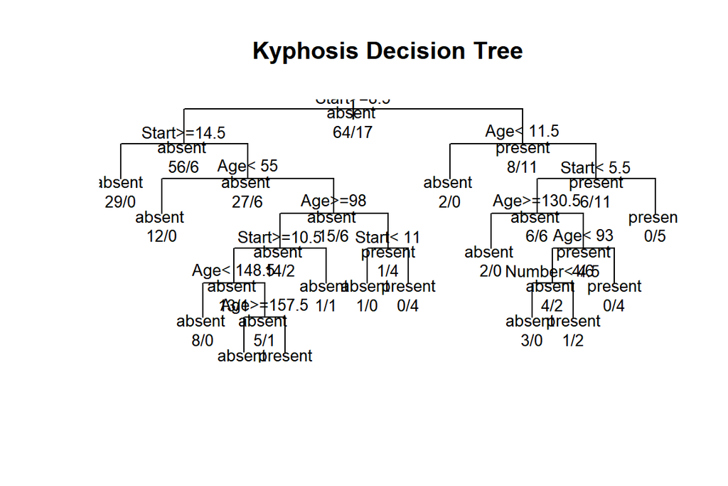

```r
plot(kmod, uniform = TRUE, main = "Kyphosis Decision Tree")
text(kmod, use.n = TRUE, all = TRUE, cex = 0.8)
```

```r
# ---------- Compare manual vs rpart numbers --------------------------------
cat("\n=== Comparison of results ===\n")
```

```
=== Comparison of results ===
```

```r
rpart_importance <- kmod$variable.importance
cat("Number of variables in rpart object:", length(rpart_importance), "\n")
```

```
Number of variables in rpart object: 3
```

```r
cat("Number of variables (method 2):",    length(manual_importance_2), "\n")
```

```
Number of variables (method 2): 3
```

```r
if (length(rpart_importance) > 0 && length(manual_importance_2) > 0) {
  comparison <- data.frame(
    Variable       = names(rpart_importance),
    rpart_value    = as.numeric(rpart_importance),
    manual_method2 = as.numeric(manual_importance_2[names(rpart_importance)]),
    manual_method3 = as.numeric(manual_importance_3[names(rpart_importance)])
  )
  comparison$diff_method2 <- abs(comparison$rpart_value - comparison$manual_method2)
  comparison$diff_method3 <- abs(comparison$rpart_value - comparison$manual_method3)

  cat("\nDetailed comparison:\n"); print(comparison)
}
```

```
Detailed comparison:
  Variable rpart_value manual_method2 manual_method3 diff_method2 diff_method3
1    Start   13.780608       18.35495             NA     4.574344           NA
2      Age   12.436761       18.71755             NA     6.280793           NA
3   Number    3.208137       13.40388             NA    10.195742           NA
```

```r
# ---------- Possible sources of discrepancy --------------------------------
cat("\n=== Possible reasons for discrepancies ===\n")
```

```
=== Possible reasons for discrepancies ===
```

```r
cat("1. Surrogate-split contributions\n")
```

```
1. Surrogate-split contributions
```

```r
cat("2. rpart's internal weighting of improve\n")
```

```
2. rpart's internal weighting of improve
```

```r
cat("3. Cross-validation or pruning adjustments\n")
```

```
3. Cross-validation or pruning adjustments
```

```r
cat("4. Numerical precision / rounding\n")
```

```
4. Numerical precision / rounding
```

```r
# ---------- Extra details from rpart object --------------------------------
cat("\n=== Extra diagnostics from rpart ===\n")
```

```
=== Extra diagnostics from rpart ===
```

```r
cat("cptable:\n"); print(kmod$cptable)
```

```
cptable:
```

```
          CP nsplit rel error   xerror      xstd
1 0.17647059      0 1.0000000 1.000000 0.2155872
2 0.11764706      1 0.8235294 1.352941 0.2387187
3 0.07843137      2 0.7058824 1.176471 0.2282908
4 0.05882353      5 0.4705882 1.235294 0.2320031
5 0.01960784     10 0.1764706 1.235294 0.2320031
6 0.00000000     13 0.1176471 1.294118 0.2354756
```

```r
cat("\nwhere vector (first few rows):\n")
```

```
where vector (first few rows):
```

```r
if (!is.null(kmod$where)) print(head(kmod$where))
```

```
 1  2  3  4  5  6
24 11 26 18  3  3
```

```r
# ---------- Exact replication via tapply -----------------------------------
calculate_exact_importance <- function(rpart_obj) {
  splits <- rpart_obj$splits
  if (is.null(splits) || nrow(splits) == 0) return(numeric(0))

  var_imp <- tapply(
    splits[, "improve"],
    sub("\\..*", "", rownames(splits)),
    sum, na.rm = TRUE
  )
  sort(var_imp, decreasing = TRUE)
}

cat("\nExact replication (tapply):\n")
```

```
Exact replication (tapply):
```

```r
exact_importance <- calculate_exact_importance(kmod)
print(exact_importance)
```

```
     Age    Start   Number
18.71755 18.35495 13.40388
```

```r
# ---------- Extra notes -----------------------------------------------------
cat("\n=== Notes on variable.importance ===\n")
```

```
=== Notes on variable.importance ===
```

```r
cat("1. Larger values = greater influence on the tree\n")
```

```
1. Larger values = greater influence on the tree
```

```r
cat("2. Based on impurity drop at each split\n")
```

```
2. Based on impurity drop at each split
```

```r
cat("3. Includes both primary and surrogate splits\n")
```

```
3. Includes both primary and surrogate splits
```

```r
cat("4. For classification trees the impurity is usually Gini or entropy\n")
```

```
4. For classification trees the impurity is usually Gini or entropy
```

```r
cat("5. rpart stores raw totals; summary() rescales to sum-to-100 (>=4.1-19) or max-to-100 (older)\n")
```

```
5. rpart stores raw totals; summary() rescales to sum-to-100 (>=4.1-19) or max-to-100 (older)
```

```r
if (length(rpart_importance) > 0) {
  rel_importance <- 100 * rpart_importance / sum(rpart_importance)
  cat("\nRelative importance (% of total):\n")
  for (i in seq_along(rel_importance)) {
    cat(sprintf("%s: %.2f%%\n",
        names(rel_importance)[i], rel_importance[i]))
  }
}
```

```
Relative importance (% of total):
Start: 46.83%
Age: 42.27%
Number: 10.90%
```